# Notebook C — Sudan DRE settlement atlas

**Purpose.** Inspect the World Bank / VIDA Distributed Renewable Energy Atlas settlement release (June 2025), check what can be reproduced, and prepare a spatial input for a future grid / mini-grid / standalone comparison.

**Reading order:** study plan → evidence and gaps → this notebook. Notebook A is a 2022 regional dispatch model; Notebook B investigates a 2012 planning report. This notebook does **not** run a post-war least-cost electrification optimization.

The source is the [Sudan DRE download](https://energydata.info/dataset/sudan-distributed-renewable-energy-dre), the accompanying data dictionary and the VIDA *DRE Atlas Planning Platform — Technical Documentation* supplied for this project. See source register and data lineage.

## 1. Definitions before numbers

| Field | What it means | What it cannot establish |
| --- | --- | --- |
| `num_connections` | Buildings ≥15 m² treated as **potential** connections | Metered customers, households or actual access |
| `demand` | Daily kWh calculated from building-size counts at fixed low service values | Measured load, industrial/critical demand, hourly peaks or a 2022 observation |
| `distance_to_existing_transmission_lines` | Straight-line km to source grid geography of mixed/unknown voltage | A feasible connection route, spare capacity or a functioning post-war line |
| `has_nightlight` | VIIRS light overlap, September 2022–August 2023 | Household electricity access; observation period spans before and after April 2023 |
| `security_risk` | ACLED fatalities near the settlement **in 2020–2022** | Current security, conflict damage or safety for travel/construction |
| `pv_value` | Long-run annual optimum PV yield, 1994–2015, kWh/kWp | Hourly solar generation or usable siting area |

The dataset release year is **2025**. The individual input layers have different dates. The atlas is a spatial screening source, not a uniform 2022 or current-year snapshot. Low historical exposure must never be interpreted as safe today.

```
33,891 sites; 41 attribute columns; 33,891 display polygons; 56 dictionary rows
```

## 2. Validation of the public files

The preprocessing script checks that the original CSV and GeoJSON contain the same 33,891 settlement IDs and field values. The GeoJSON polygons are valid. It saves the full attributes and display-only polygons simplified to a 100 m tolerance. For route design, download the original GeoJSON rather than using those simplified outlines. The immutable hashes, code and small discrepancies are in the validation report.

```
Demand formula: 33,891/33,891 rows within ±0.05 kWh/day rounding
Historical risk class: 33,891/33,891 rows reproduce the 25/50 km fatality rule
```

|  | Check | Count |
| --- | --- | --- |
| 0 | Unique IDs | 33891 |
| 1 | Valid display polygons | 33891 |
| 2 | Missing state label | 21 |
| 3 | Missing relative wealth index | 33868 |
| 4 | Nightlight flag/overlap disagreement | 1 |
| 5 | Road flag/rounded distance disagreement | 7 |
| 6 | Building density >100% | 4 |

The seven road discrepancies lie at a reported distance of exactly 0.50 km, where rounding can change a strict 500 m test. The nightlight disagreement and four density values above 100% are retained as source issues. The wealth index covers only **23** of 33,891 sites; it is unusable as a countrywide affordability layer.

## 3. Scale and service level

All national totals below are **sums of modeled settlement attributes**. Population is not a census count; potential connections are eligible buildings. The atlas load deliberately uses a small per-building daily energy allowance.

|  | Quantity | Value |
| --- | --- | --- |
| 0 | Settlement clusters | 33,891 |
| 1 | Potential building connections | 17,589,336 |
| 2 | Modeled population in clusters | 50,042,901 |
| 3 | Atlas demand (GWh/day) | 6.277 |
| 4 | Atlas demand annualized (TWh/year) | 2.291 |
| 5 | National 2022 consumer electricity (TWh/year) | 13.261 |

```
Atlas low-service annualization / 2022 national consumer electricity = 17.3%
This ratio compares different coverage and definitions; it is not a validation residual.
```

The 2022 comparison uses the national consumer electricity figure already documented in Notebook A. It shows why the atlas demand cannot simply replace national load: it implies roughly **2.29 TWh/year** at the prescribed low service level versus **13.261 TWh** of national consumer electricity in 2022. Commercial, industrial, public-service and suppressed demand, actual connection status and service quality need separate treatment. No nationwide scaling factor is inferred from this mismatch.

## 4. Where are the mapped clusters and modeled demand?

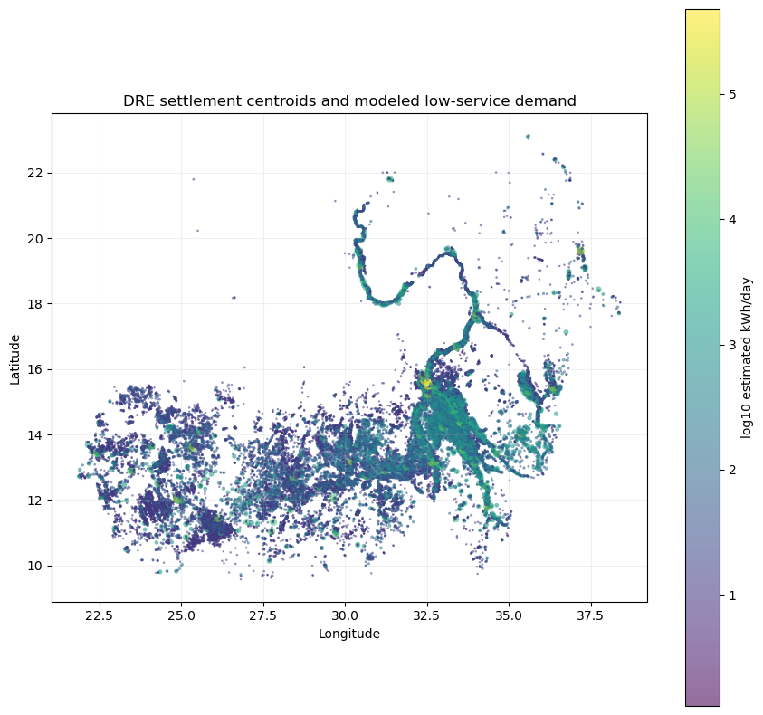

|  | admin_cgaz_1 | clusters | potential_connections | demand_kwh_day | modeled_population |
| --- | --- | --- | --- | --- | --- |
| 0 | Khartoum | 1818 | 3779944 | 1446088.7 | 9459922 |
| 1 | Gezira | 2842 | 2663000 | 940538.4 | 7973875 |
| 2 | North Kordofan | 4017 | 1237753 | 423496.7 | 3762874 |
| 3 | White Nile | 2090 | 1215012 | 421581.9 | 3611788 |
| 4 | River Nile | 2072 | 870464 | 317358.6 | 2569060 |
| 5 | Sennar | 1101 | 907503 | 310963.2 | 2716681 |
| 6 | Kassala | 1231 | 876856 | 309701.3 | 2513153 |
| 7 | North Darfur | 3078 | 861529 | 293283.5 | 2404475 |
| 8 | Gedaref | 835 | 820407 | 282236.5 | 2372357 |
| 9 | West Kordofan | 3972 | 777453 | 264987.6 | 2426306 |
| 10 | South Darfur | 3003 | 770756 | 262896.6 | 2061303 |
| 11 | Northern | 1345 | 642743 | 253040.7 | 2027926 |
| 12 | Blue Nile | 542 | 478510 | 163183.5 | 1355032 |
| 13 | Red Sea | 431 | 405275 | 150673.6 | 1037956 |
| 14 | South Kordofan | 1679 | 392626 | 134095.6 | 1209287 |
| 15 | East Darfur | 1981 | 357203 | 120976.7 | 978753 |
| 16 | West Darfur | 882 | 282006 | 96687.6 | 800209 |
| 17 | Central Darfur | 951 | 243899 | 82937.5 | 741234 |

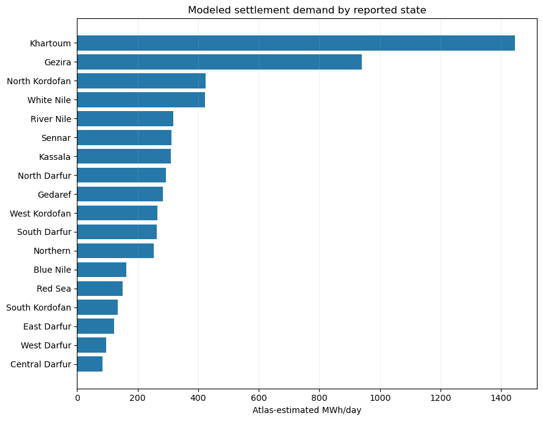

The map and state aggregation describe **where the source has identified buildings**, not where a new plant should be built. Missing state names are excluded from the state chart but remain in all-country totals. Repeated district agricultural values are not summed: those fields describe an administrative area and repeat for its settlements.

## 5. Grid proximity, nightlights and historical exposure

These screens guide pilot selection and data collection. A settlement close to a line may still face destroyed infrastructure, insufficient capacity, an absent transformer or a costly route. Nightlights and 2020–2022 risk classes have distinct dates and meanings.

| grid_distance_band | clusters | potential_connections | modeled_demand_kwh_day | nightlight_sites | road_access_sites |
| --- | --- | --- | --- | --- | --- |
| ≤5 km | 3956 | 7525444 | 2804233.3 | 1294 | 1145 |
| 5–25 km | 7455 | 4241529 | 1486975.5 | 1968 | 869 |
| 25–100 km | 6447 | 2183464 | 745197.8 | 498 | 332 |
| >100 km | 16033 | 3638899 | 1240546.2 | 158 | 670 |

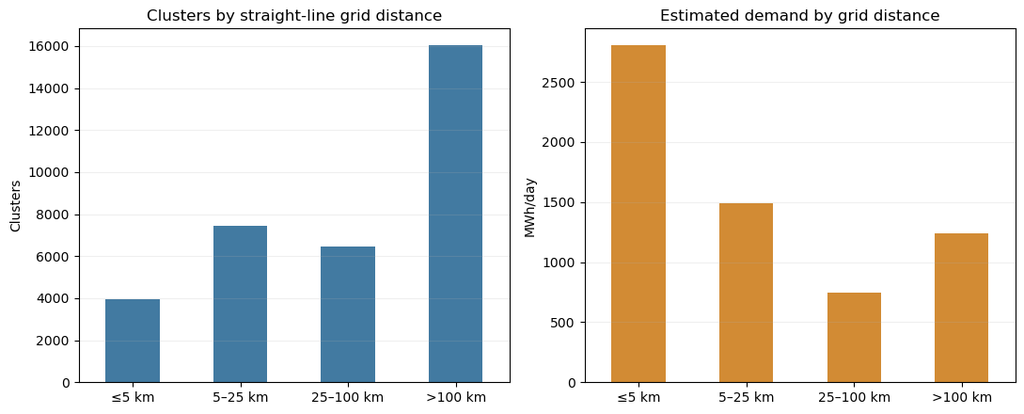

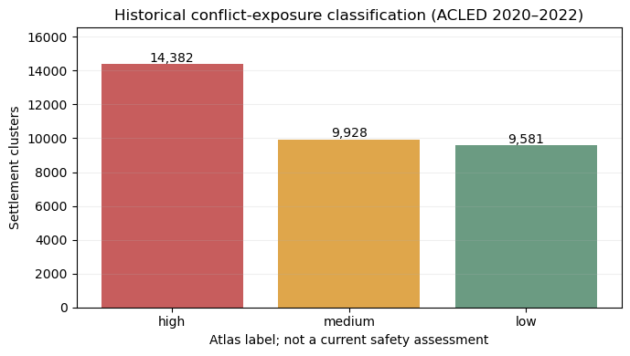

```
Sites showing atlas nightlight overlap: 3,918 / 33,891
```

## 6. An input table for the next model

The repository stores the **full 41 attribute fields** and simplified display geometry by `geohash`. A pilot can join these fields to verified assets and alternative demand/service scenarios. The source daily energy can be annualized for a *scenario*, but dividing by 24 gives average power only; an hourly profile and peak requirement remain unknown. No economic option is assigned in this notebook.

|  | geohash | lat | lon | admin_cgaz_1 | admin_cgaz_2 | potential_building_connections | atlas_modeled_population | atlas_low_service_kwh_day | straight_line_grid_distance_km | dist_main_road_km | long_run_pv_yield_kwh_per_kwp_year | has_nightlight | historical_conflict_exposure_2020_2022 | atlas_mean_mw | atlas_annual_kwh_if_repeated |
| --- | --- | --- | --- | --- | --- | --- | --- | --- | --- | --- | --- | --- | --- | --- | --- |
| 0 | s6puxbs9g3 | 12.044 | 22.495 | NaN | NaN | 167 | 571 | 56.7 | 795.28 | 3.29 | 1794.943 | False | high | 0.002 | 20695.5 |
| 1 | s6pvrxuek5 | 12.216 | 22.484 | West Darfur | Foro Baranga | 144 | 492 | 48.2 | 795.05 | 11.71 | 1798.710 | False | high | 0.002 | 17593.0 |
| 2 | s6pvxrt8tk | 12.258 | 22.475 | West Darfur | Habila - WD | 145 | 496 | 48.9 | 795.95 | 11.37 | 1797.907 | False | high | 0.002 | 17848.5 |
| 3 | s6pvzc68kf | 12.268 | 22.493 | West Darfur | Habila - WD | 68 | 232 | 22.8 | 793.97 | 9.95 | 1801.413 | False | high | 0.001 | 8322.0 |
| 4 | s6pvzpn0d3 | 12.299 | 22.464 | West Darfur | Habila - WD | 232 | 793 | 77.7 | 796.63 | 7.76 | 1798.126 | False | high | 0.003 | 28360.5 |
| 5 | s6pvzyz2ve | 12.298 | 22.499 | West Darfur | Habila - WD | 61 | 208 | 20.4 | 793.06 | 6.51 | 1802.966 | False | high | 0.001 | 7446.0 |
| 6 | s6pxgx7b37 | 12.652 | 21.956 | West Darfur | Beida | 46 | 157 | 15.4 | 851.21 | 24.16 | 1807.987 | False | high | 0.001 | 5621.0 |
| 7 | s6pyp0w9x0 | 12.308 | 22.465 | West Darfur | Habila - WD | 383 | 1309 | 129.7 | 796.26 | 6.87 | 1798.166 | False | high | 0.005 | 47340.5 |

```
Pilot-input rows: 33891 — assumptions for service, hourly demand and technology costs are still required.
```

## 7. What this enables, and what remains

**Now possible:** choose representative settlement clusters across location, size, grid-distance and road-access conditions; construct demand scenarios with traceable origins; compare the published risk labels to their underlying 2020–2022 fatality rule; compare modeled regional distributions; and review the original polygons in GIS. The saved source is released under **CC BY 4.0** with attribution in SOURCE_REGISTER.md.

**Still required for least-cost choices:** verified usable/repairable grid geometry and capacity; realistic candidate routes and transformers; damage/repair scenarios; household, public-service and productive demand with hourly profiles and comparable service standards; 2022/post-war calibration data; PV/hydro/wind chronology; lifecycle technology/distribution/connection costs; finance assumptions; and independent local validation. A [2009 transmission shapefile](https://energydata.info/dataset/sudan-electricity-transmission-network) exists but predates South Sudan's separation and the war and cannot establish functioning current lines. See the study plan.

**Next experiment:** select a small, explicitly documented set of diverse clusters, verify their network context, specify the same service requirement for grid, mini-grid and standalone systems, and run a cost-complete sensitivity analysis. Expand nationally only after the pilot checks pass.